# Indice

- Setup e Caricamento Dati
- Feature Engineering
- 1. Panoramica: Member vs Casual
- 2. Analisi Temporale
  - 2.1 Pattern Intragiornalieri (Orario)
  - 2.2 Pattern Stagionali (Mensile)
- 3. Analisi Spaziale: Zoning Districts di Chicago
  - 3.1 Caricamento Dati e Spatial Join
  - 3.2 Validazione Statistica — Test Chi-Quadro
  - 3.3 Distribuzione per Zona: Member vs Casual
  - 3.4 Pattern Viaggio Zona-Zona
  - 3.5 Analisi della Divergenza
  - 3.6 Mappa Conversione
- 4. Conclusioni e Raccomandazioni
- 5. Salvataggio Output

# Setup e Caricamento Dati

↑ back to top

```
Rows    : 5,614,731
Columns : 13
Columns : ['ride_id', 'rideable_type', 'started_at', 'ended_at', 'start_station_name', 'start_station_id', 'end_station_name', 'end_station_id', 'start_lat', 'start_lng', 'end_lat', 'end_lng', 'member_casual']
```

# Feature Engineering

↑ back to top

Prima di iniziare l'analisi aggiungo tre colonne derivate:

1. **`trip_duration`** — durata del viaggio in minuti (con cap a 1 min – 24h per escludere outlier).
2. **`day_category`** — classifica ogni giorno come `weekday`, `weekend` o `holiday` (festivi Illinois).
3. **`ride_date`** — data normalizzata della partenza, usata per il conteggio dei giorni unici.

```
converting in datetime ( if not already ) started at: datetime64[ns] ended at: datetime64[ns]
```

```
From 5,614,731 to 5,462,857 rows (2.70% removed as duration outliers)
trip_duration — min: 1.0 min  max: 1440.0 min  median: 9.7 min
```

### Categoria giornaliera: weekday / weekend / holiday

Uso la libreria `holidays` per identificare i festivi dell'Illinois e classifico ogni viaggio in una delle tre categorie con un approccio vettorizzato (nessun iterrow).

↑ back to top

```
Date range       : 2025-03-31 → 2026-03-31
Illinois holidays in range : 13
```

```
STEP 1: CREATE DAY CATEGORY COLUMN (VECTORIZED)...
```

```
Total ride distribution:
day_category
weekday    3768927
weekend    1541113
holiday     152817
Name: count, dtype: int64
```

Le tre categorie separano contesti comportamentali distinti:

- **Weekday** — dominato probabilmente dai pendolari (member).
- **Weekend + Holiday** — dominato probabilmente da corse leisure (casual).

La sezione 1 verificherà questa ipotesi a livello macro.

↑ back to top

# 1. Panoramica: Member vs Casual

↑ back to top

Prima di entrare nei dettagli temporali e spaziali, voglio capire a grandi linee come si distribuisce l'utilizzo tra le due tipologie di utente nei giorni feriali rispetto ai fine settimana/festivi.

Un'asimmetria netta è il primo segnale che i due gruppi hanno abitudini d'uso strutturalmente diverse — commuting vs. tempo libero.

```
=======================================================
STEP 0 ✅ Date columns converted & 'ride_date' created
  → Total rows  : 5,462,857
  → Date range  : 2025-03-31 → 2026-03-31
  → Unique days : 366
  ⏱ Step 0: 1.677s
```

```
=======================================================
STEP 1 ✅ Dataset split into 4 segments (no copies)
  → Weekday  | Member : 2,621,964 rides
  → Weekday  | Casual : 1,146,963 rides
  → Weekend  | Member :  909,877 rides
  → Weekend  | Casual :  784,053 rides
  → Total   (check)  : 5,462,857 rides
  ⏱ Step 1: 0.386s
```

```
=======================================================
STEP 2+3 ✅ Single groupby replaces function + 4 calls
  Segment                  Tot. min   Days  Avg min/day
  ----------------------------------------------------
  Weekday  | Member      31,109,081    249    124,936.1
  Weekday  | Casual      20,515,602    249     82,392.0
  Weekend  | Member      12,153,929    117    103,879.7
  Weekend  | Casual      17,755,433    117    151,755.8
  ⏱ Step 2+3: 0.514s

=======================================================
STEP 4 ✅ Pie chart percentages computed
  → MEMBER  — Weekday: 54.6%  |  Weekend: 45.4%
  → CASUAL  — Weekday: 35.2%  |  Weekend: 64.8%
  ⏱ Step 4: 0.000s
```

```
=======================================================
STEP 5 ✅ Raw values — final sanity check
WEEKDAY MEMBER : 31109080.6 249 124936.06666666667
WEEKEND MEMBER : 12153929.41 117 103879.73854700854
WEEKDAY CASUAL : 20515602.25 249 82391.97690763052
WEEKEND CASUAL : 17755433.08 117 151755.83829059827
  → Temp column 'day_cat_simple' removed ✅
=======================================================
```

# 2. Analisi Temporale

↑ back to top

La panoramica iniziale ha mostrato come member e casual si distribuiscano diversamente tra giorni feriali e festivi. Qui voglio scendere nel dettaglio: **quando** durante la giornata e **in quali mesi** i due gruppi utilizzano il servizio in modo più divergente.

## 2.1 Pattern Intragiornalieri (Orario)

↑ back to top

Mi aspetto che i member mostrino doppi picchi negli orari di pendolarismo (8:00 e 17-18:00), mentre i casual dovrebbero concentrarsi nelle ore centrali del pomeriggio — coerente con un uso leisure.

La metrica è **ore totali di utilizzo per giorno** (normalizzate per il numero di giorni unici in ciascun gruppo), per correggere lo sbilanciamento tra giorni feriali e festivi.

```
=======================================================
STEP 0 ✅ Group encoding done
  → weekday_member      : 2,621,964 rides |  249 days
  → weekday_casual      : 1,146,963 rides |  249 days
  → weekend_member      :  909,877 rides |  117 days (weekend + holiday)
  → weekend_casual      :  784,053 rides |  117 days (weekend + holiday)
  ⏱ Step 0: 0.945s
```

```
=======================================================
STEP 1 ✅ Numba: single pass completed
  → Output shape: (4, 24)  (4 groups × 24 hours)
  → Total minutes processed: 81,534,045
  ⏱ Step 1: 0.525s

=======================================================
STEP 2 ✅ Normalization done
  → weekday_member      : peak hour 17:00 → 265.411 h/day
  → weekday_casual      : peak hour 17:00 → 142.987 h/day
  → weekend_member      : peak hour 16:00 → 142.535 h/day
  → weekend_casual      : peak hour 15:00 → 235.879 h/day
  ⏱ Step 2: 0.001s

=======================================================
STEP 3 ✅ Colors and titles configured
  → Weekday: #ff4444 (red) | Weekend+Holiday: #4477ff (blue)
```

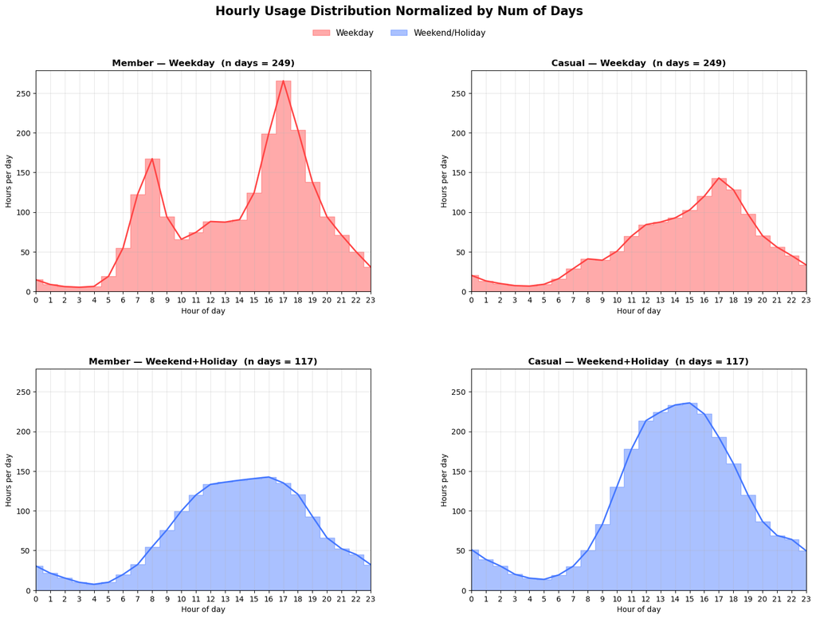

```
=======================================================
STEP 5 ✅ Export done + temporary columns removed
  → ../reports/figures/hourly_usage_weekday_vs_weekend.png
  → ../data/processed/hourly_usage.csv
  → Column 'group_id' removed from df_clean ✅

  ⏱ TEMPO TOTALE: 2.461s
=======================================================
```

```
============================================================
STEP 13 — Interactive Hourly Usage with monthly filter
============================================================
```

```
  → Months available : 13  (2025-03 → 2026-03)
```

```
  → Datasets computed: 14  (All + 13 months)
```

```
✅ Saved: ../reports/cyclistic_hourly_interactive.html
   → 56 total traces (14 options × 4 groups × 2 layer fill/line)
   ⏱ 21.830s
```

## 2.2 Pattern Stagionali (Mensile)

↑ back to top

Stabilito *quando* durante la giornata ciascun gruppo pedala, voglio ora guardare *quali mesi* mostrano i picchi più alti. Mi aspetto che i casual abbiano una curva stagionale più ripida — il loro utilizzo è più sensibile al meteo e legato al turismo — mentre i member dovrebbero mantenersi più costanti durante l'anno.

```
============================================================
STEP 0 [OK] Numba function 'compute_minutes' defined
  → Input : start_ns, end_ns (int64 nanoseconds)
  → Output: float64 array di durate in minuti
  → Gestione: end <= start → 0.0 (riga scartata)

============================================================
STEP 1+2 ✅ Preparazione dati mensili in corso...
```

```
  [OK] 'started_at' already datetime — skipping conversion
  [OK] 'trip_duration' already present — Numba not needed
```

```
  ⏱ prepare_monthly_usage: 1.635s

  → Months in dataset  : 13
  → Period             : 2025-03  →  2026-03
  → Total hours member  :      721,050
  → Total hours casual  :      637,851
  → Total hours combined:    1,358,901
  ⏱ Step 1+2: 1.768s

============================================================
STEP 3 [OK] Y-axis scale computed
  → Max hours in a month:    116,983
  → Y max (rounded)     :    120,000  (12 indices)
  → Scale               : 1 index = 10,000 hours
```

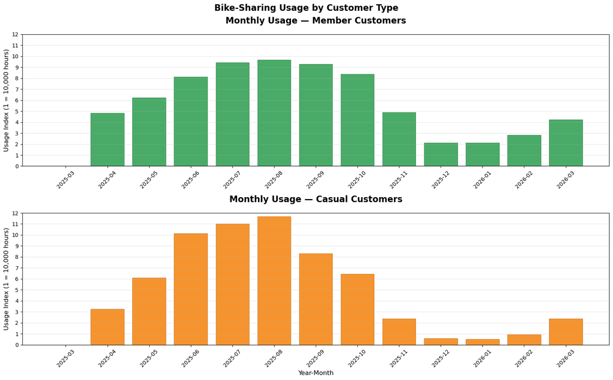

```
============================================================
STEP 4 [OK] Export complete
  → ../reports/figures/monthly_usage_member_vs_casual.png
  → ../data/processed/monthly_usage.csv

  Last 5 months (most recent):
Year_Month  Member_Hours  Casual_Hours
   2025-11  48934.172333  23797.392500
   2025-12  21321.786333   5811.300500
   2026-01  21207.687167   5178.227833
   2026-02  28173.652500   9410.917167
   2026-03  42211.675000  23853.613667

  ⏱ TEMPO TOTALE: 2.174s
============================================================
```

# 3. Analisi Spaziale: Zoning Districts di Chicago

↑ back to top

I pattern temporali mi hanno detto *quando* ciascun gruppo pedala. Ora voglio capire *dove*: member e casual partono e arrivano in zone strutturalmente diverse della città?

Ogni viaggio viene geolocalizzato usando il dataset di zoning di Chicago (14.757 poligoni). Lo spatial join assegna a ciascuna partenza e arrivo il distretto di zoning corrispondente.

## 3.1 Caricamento Dati e Spatial Join

↑ back to top

**Dati:** `gdf_zoning_updated.csv` da `../data/interim/` — 14.757 poligoni di zoning con etichette `zone_name` semplificate.

**Metodo:** spatial join GeoPandas (`sjoin` con `predicate="within"`) — assegna a ciascuna partenza e arrivo il distretto di zoning corrispondente.

```
Loading Zoning Districts
--------------------------------------------------
```

```
Verifying required columns
--------------------------------------------------
[OK] Zones loaded: 14,875 districts
   Unique zone_name: 7
   Unique zone_type: 12
   Available zone_type: [np.int64(1), np.int64(2), np.int64(3), np.int64(4), np.int64(5), np.int64(6), np.int64(7), np.int64(8), np.int64(9), np.int64(10), np.int64(11), np.int64(12)]
   CRS: EPSG:4326
   Bounds: lat [41.6446, 42.0230] lng [-87.9401, -87.5241]
```

```
Preparing df_clean for spatial join
--------------------------------------------------
```

```
df_clean: 5,462,857 rides, 19 columns
```

```
   Coordinate bounds (4/4 available):
     start_lat  start_lng  end_lat  end_lng
min    41.6485     -87.89    41.49   -88.10
max    42.0700     -87.52    42.21   -87.42
   member_casual: {'member': 3531841, 'casual': 1931016}
   All columns: ['ride_id', 'rideable_type', 'started_at', 'ended_at', 'start_station_name', 'start_station_id', 'end_station_name', 'end_station_id', 'start_lat', 'start_lng', 'end_lat', 'end_lng', 'member_casual', 'trip_duration', 'is_holiday', 'day_category', 'ride_date', 'day_cat_simple', 'group…
```

```
Creating GeoDataFrames for trip start and end points
--------------------------------------------------
```

```
✅ gdf_starts CRS: EPSG:4326
✅ gdf_ends CRS: EPSG:4326
```

```
   Bounds (starts): [-87.89        41.64850076 -87.52        42.07      ]
```

```
   Bounds ends: [-88.1   41.49 -87.42  42.21]
```

```
Spatial Join — Start Locations
--------------------------------------------------
```

```
✅ START join:
   Rides with zone assigned: 5,369,000/5,462,857 (98.3%)
   Zone name uniche: 7
```

```
Spatial Join — End Locations
--------------------------------------------------
```

```
✅ END join:
   Rides with zone assigned: 5,366,522/5,462,857 (98.2%)
```

```
Filtering and Segmentation
--------------------------------------------------
```

```
✅ df_zoning: 5,323,808 rides (2.5% loss)
   Member: 3,460,856 | Casual: 1,862,952
   Member/Casual ratio: 1.9x
```

```
Debiased Patterns — % per user group (normalized to remove size imbalance)
============================================================
Member rides: 3,460,856 | Casual rides: 1,862,952 | Ratio: 1.9x
```

```
🔴 TOP 10 MEMBER (% sul totale member):
                                                          pattern  rides  pct_member
Planned Manufacturing Districts → Planned Manufacturing Districts 647462       18.71
                                              Business → Business 253560        7.33
                       Planned Manufacturing Districts → Business 248274        7.17
                       Business → Planned Manufacturing Districts 239614        6.92
                       Downtown → Planned Manufacturing Districts 221452        6.40
                       Planned Manufacturing Districts → Downtown 219637        6.35
                    Planned Manufacturing Districts → Residential 144101        4.16
                    Residential → Planned Manufacturing Districts 143950        4.16
                                           Residential → Business 123844        3.58
                                           Business → Residential 123624        3.57

🔵 TOP 10 CASUAL (% sul totale casual):
                                                          pattern  rides  pct_casual
Planned Manufacturing Districts → Planned Manufacturing Districts 515297       27.66
                                              Business → Business 121861        6.54
                       Planned Manufacturing Districts → Business 118545        6.36
                       Business → Planned Manufacturing Districts 114353        6.14
                       Downtown → Planned Manufacturing Districts 110749        5.94
                       Planned Manufacturing Districts → Downtown 110090        5.91
                    Planned Manufacturing Districts → Residential  71972        3.86
                    Residential → Planned Manufacturing Districts  66012        3.54
                                        Residential → Residential  64189        3.45
                                           Business → Residential  63685        3.42
```

```
Crosstab — zone-to-zone ride flow matrix (% row-normalised)
----------------------------------------
```

```
  → Zones          : ['Business', 'Commercial', 'Downtown', 'Manufacturing', 'Planned Manufacturing Districts', 'Residential', 'Transportation']
  → Shape          : (7, 7)
  → Row-sum member : {'Business': 100.0, 'Commercial': 100.0, 'Downtown': 100.0, 'Manufacturing': 100.0, 'Planned Manufacturing Districts': 100.0, 'Residential': 100.0, 'Transportation': 100.0}
  → Row-sum casual : {'Business': 100.0, 'Commercial': 100.0, 'Downtown': 100.0, 'Manufacturing': 100.0, 'Planned Manufacturing Districts': 100.0, 'Residential': 100.0, 'Transportation': 100.0}
  ✅ Each row sums to ~100 % — normalisation correct
```

## 3.2 Statistical Validation — Chi-Square Test

↑ back to top

Before investing in visual analysis, we formally test whether the observed zone distribution  
differences between members and casuals are statistically significant or could be due to chance.

**H₀:** the start zone distribution is independent of user type (member vs. casual).  
A very low p-value (< 0.001) rejects H₀ and confirms the differences are real.

```
Chi-Square Independence Test — Start Zone vs User Type
----------------------------------------
```

```
START zone_type → Chi²=26062, p=0.00e+00 ✅ SIGNIFICANT
```

```
END zone_type → Chi²=31351, p=0.00e+00 ✅ SIGNIFICANT
```

## 3.3 Start Zone Distribution: Member vs Casual

↑ back to top

**Zoom:** the chi-square test confirmed that zone distributions differ significantly.  
This chart shows *which specific zones* account for that divergence:

- Upper panel: raw % of rides starting from each zone (by user type).
- Lower panel: divergence (member % − casual %) — green bars = member over-representation,  
  orange bars = casual over-representation.

```
============================================================
Start Zone Distribution — Member vs Casual
============================================================
```

```
  → Zone trovate             : 7
  → Most used zone (member): Planned Manufacturing Districts  (40.0%)
  → Most used zone (casual): Planned Manufacturing Districts  (47.0%)
  → Max divergence member  : Business  (+2.7%)
  → Max divergence casual  : Planned Manufacturing Districts  (+7.0%)
```

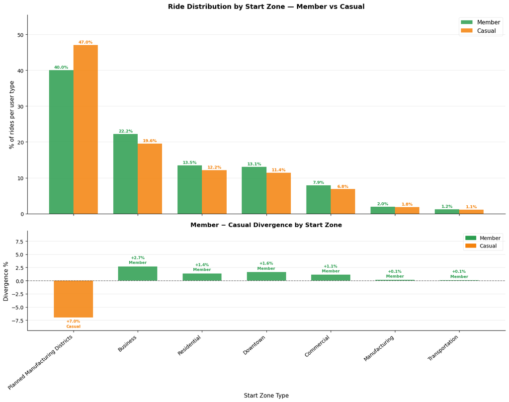

```
  Summary table (sorted by divergence):
                                 member_%  casual_%  divergence_%
start_zone_name
Business                             22.2      19.6          2.68
Downtown                             13.1      11.4          1.62
Residential                          13.5      12.2          1.36
Commercial                            7.9       6.8          1.11
Manufacturing                         2.0       1.8          0.14
Transportation                        1.2       1.2          0.08
Planned Manufacturing Districts      40.0      47.0         -6.99

✅ Saved: start_zone_distribution_divergence.png  ⏱ 1.593s
```

## 3.4 Zone-to-Zone Ride Patterns

↑ back to top

**Zoom:** we now look beyond start zones to the full origin → destination matrix.  
Each cell in the heatmap shows what percentage of a user type's rides go from a given  
start zone (row) to a given end zone (column) — normalized within each user group  
to remove the size imbalance between members and casuals.

Clusters along the diagonal indicate local (same-zone) rides; off-diagonal patterns  
reveal cross-zone commute or leisure corridors.

```
============================================================
ZONE INFRASTRUCTURE & PERFORMANCE ANALYSIS
============================================================
```

```
STEP 0 ✅ Unique stations: 3,236
STEP 1 ✅ Station GeoDataFrame — CRS: EPSG:4326

STEP 2   Preparing zoning GeoDataFrame...
```

```
STEP 2 ✅ Zoning polygons: 14,757
  → Zone names: ['Business', 'Commercial', 'Downtown', 'Manufacturing', 'Planned Manufacturing Districts', 'Residential', 'Transportation']

STEP 3 ✅ Spatial join complete
  → Matched   : 2,963 stations
  → Unmatched : 273 (8.4% — outside all zone polygons)

STEP 4 ✅ Infrastructure by zone  (dock_count: not available)
  Zone                                  Stations
  -----------------------------------------------
  Business                                 1,251
  Planned Manufacturing Districts            776
  Residential                                370
  Commercial                                 359
  Manufacturing                              114
  Downtown                                    74
  Transportation                              19
```

```
STEP 5 ✅ Rides by zone
  Zone                                   R_m_start    R_c_start    R_m_end    R_c_end
  ---------------------------------------------------------------------------------
  Planned Manufacturing Districts        1,395,047      886,496  1,384,960    874,913
  Business                                 774,900      368,792    787,170    369,794
  Residential                              470,793      229,074    469,630    244,598
  Downtown                                 454,984      215,710    449,220    208,554
  Commercial                               276,329      128,551    277,749    129,430
  Manufacturing                             69,048       34,691     69,773     36,102
  Transportation                            42,924       21,661     43,200     21,429

STEP 6 ✅ Rides-per-station computed
STEP 7 ✅ Performance indices computed

============================================================
ZONE METRICS  (sorted by I_diff  ↓  Member overperformance)
============================================================
                      zone_name  n_stations_zone  rides_per_station_member  rides_per_station_casual   I_m   I_c  I_diff
                       Downtown               74                   6148.43                   2915.00 5.229 4.582   0.647
                 Transportation               19                   2259.16                   1140.05 1.921 1.792   0.129
                    Residential              370                   1272.41                    619.12 1.082 0.973   0.109
                     Commercial              359                    769.72                    358.08 0.655 0.563   0.092
                       Business             1251                    619.42                    294.80 0.527 0.463   0.063
                  Manufacturing              114                    605.68                    304.31 0.515 0.478   0.037
Planned Manufacturing Districts              776                   1797.74                   1142.39 1.529 1.796  -0.267

  CONVERSION TARGETS — Casual outperforms Member (I_diff < 0)
  Zone                                   I_m    I_c   I_diff  rides/stn M  rides/stn C
  -----------------------------------------------------------------------------------
  Planned Manufacturing Districts      1.529  1.796   -0.267       1797.7       1142.4

  MEMBER STRONGHOLDS — Member outperforms Casual (I_diff > 0)
  Zone                                   I_m    I_c   I_diff  rides/stn M  rides/stn C
  -----------------------------------------------------------------------------------
  Downtown                             5.229  4.582   +0.647       6148.4       2915.0
  Transportation                       1.921  1.792   +0.129       2259.2       1140.0
  Residential                          1.082  0.973   +0.109       1272.4        619.1
  Commercial                           0.655  0.563   +0.092        769.7        358.1
  Business                             0.527  0.463   +0.063        619.4        294.8
  Manufacturing                        0.515  0.478   +0.037        605.7        304.3

✅ zone_metrics ready — 7 zones  ⏱ 4.473s
============================================================
```

### Infrastructure Context: Stations Across Chicago's Zoning Districts

↑ back to top

Before examining trip patterns by zone, it is worth seeing **where the infrastructure actually is.** Chicago's land-use zoning shapes who rides and why — a dense Business district drives weekday commutes (membership use), while a mixed-use Planned Manufacturing District with bars, cafés and parks draws weekend leisure riders (casual use).

The map below shows the seven zoning categories with their polygon boundaries, the station count within each zone, and a **performance index** in the panel below:

> **I = zone's share of all rides ÷ zone's share of all stations** Values above 1 mean the zone generates *more* rides than its infrastructure share would predict; values below 1 indicate under-performance.

```
  -> Macro-zones: 7  |  Stations: 3,236
```

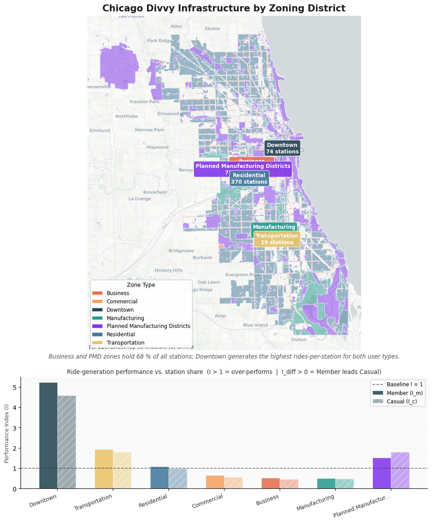

```
[OK] Saved: chicago_zone_map_basemap.png  [15.0s]
```

## 3.5b Infrastructure Map — Key Observations

↑ back to top

[output not shown]

**Two findings stand out:**

1. **Downtown is infrastructure-scarce but ride-dense.** With only ~2.5 % of all stations it accounts for a disproportionate share of rides for *both* user types. Any station expansion here has near-instant payback for ridership.
2. **Planned Manufacturing Districts show the strongest Casual over-performance (I_c > I_m).** This is the zone where marketing investment in conversion will find the most receptive casual audience — they are already riding, just not as members.

### Conversion Opportunity: Station-Level View

↑ back to top

The zone map showed that **Planned Manufacturing Districts** is the highest-priority zone for conversion. This map zooms in to the station level — one bubble per station — revealing *exactly where* within the city casual riders concentrate.

**Reading guide:**

- **Color** = member share at that station (orange → casual majority; green → member majority; white → balanced ≈50/50).
- **Bubble size** ∝ √(annual trips): larger bubbles mean more total volume.
- **Red rings** mark the top-10 stations by absolute casual ride count — the addresses where a conversion campaign would have the highest immediate impact.

Only stations with ≥ 100 annual trips are shown to remove low-volume noise.

```
  -> Stations total: 3,236  |  Shown (>=100 trips/yr): 1,492
```

[figure not shown]

```
Top-10 conversion targets (highest casual ride volume):
  Station ID                Zone                                 Member%   Casual    Total
  -------------------------------------------------------------------------------------
  CHI01747                  Planned Manufacturing Districts        21.7%   44,528   56,864
  CHI00374                  Planned Manufacturing Districts        21.4%   25,922   32,989
  CHI00252                  Planned Manufacturing Districts        36.0%   19,344   30,239
  CHI00525                  Planned Manufacturing Districts        42.3%   16,807   29,113
  CHI01742                  Planned Manufacturing Districts        31.0%   15,663   22,701
  CHI00420                  Planned Manufacturing Districts        42.0%   13,746   23,698
  CHI00533                  Planned Manufacturing Districts        18.3%   13,730   16,810
  CHI00531                  Planned Manufacturing Districts        26.9%   12,450   17,039
  CHI01163                  Planned Manufacturing Districts        35.0%    9,410   14,468
  CHI00427                  Planned Manufacturing Districts        40.9%    8,989   15,213

[OK] Saved: chicago_conversion_map.png  [2.6s]
```

## 3.6 Conversion Map — Key Observations

↑ back to top

**What the map reveals:**

- **Lakefront Trail (east side):** the densest cluster of large orange bubbles runs along DuSable Lake Shore Drive from Grant Park north through Lincoln Park. These stations serve leisure cyclists, tourists and park users — high casual volume, very low member share. All 10 top conversion targets fall in this corridor or the adjacent PMD neighbourhoods.
- **Downtown (centre):** stations are green-to-neutral. Even in a high-tourism zone, members outnumber casuals because weekday commuters pass through here every day.
- **North Side residential grid:** stations turn green. Neighbourhood commuters are already converted; re-investment here has low marginal conversion yield.
- **Balanced band (~50/50, white):** a transitional ring between the leisure-heavy east and the commuter-heavy north. Riders here already use both modes — the lowest-friction conversion opportunity via in-app messaging.

**Conversion implications:**

| Priority | Area | Recommended action |
| --- | --- | --- |
| **High** | Lakefront Trail stations (top-10) | Seasonal "summer pass → annual upgrade" bundles at unlock point |
| **High** | PMD mixed-use cluster (Wicker Park / Logan Square) | Neighbourhood ambassador programmes; event partnerships |
| **Medium** | Balanced stations (white bubbles) | In-app cost-savings prompts ("You've taken X rides — a membership saves you $Y") |
| **Low** | Member-green stations | Retention; upsell (e-bike add-ons, family plans) |

### Key Conversion Zones at a Glance

↑ back to top

> **Filter:** casual-majority stations (member share < 45 %) with ≥ 300 annual trips.

All other active stations appear as faint grey dots — spatial context only. Orange bubbles are the conversion targets, sized by their casual ride volume. The annotated callouts identify the two primary geographic clusters.

```
  -> Active stations (>=300 trips/yr): 1,151
  -> Conversion targets (member share <45%): 61
  -> Context (member-heavy / balanced):         1,090
```

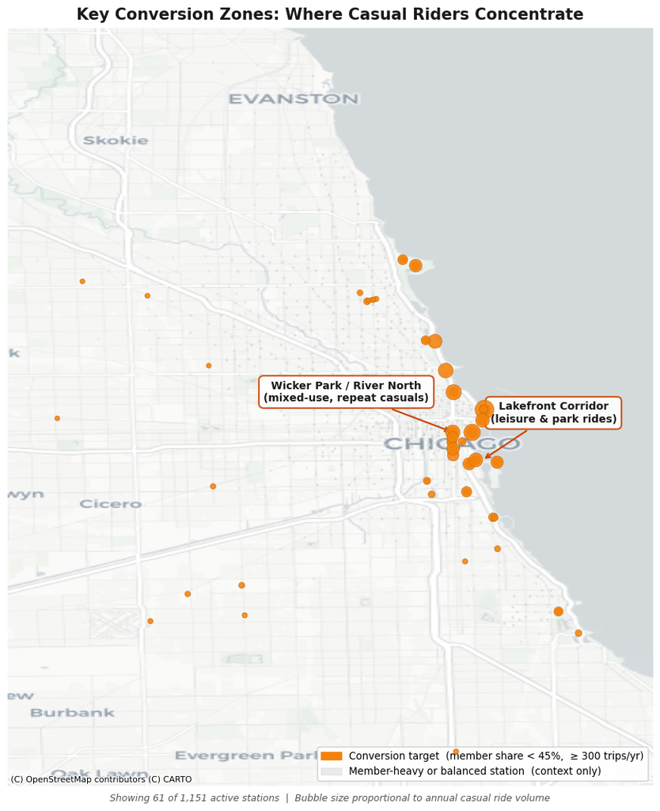

```
[OK] Saved: chicago_insight_map.png  [0.7s]
```

[figure not shown]

```
[OK] Saved: chicago_insight_map_poi.png  [0.8s]
     POI counts: {'Universities': 6, 'Transport Hubs': 7, 'Tourist Attractions': 8, 'Schools (selected)': 5, 'Business Districts': 6}
```

## 3.7b Conversion Zones + POI Overlay — Interpretation

↑ back to top

### What was added

The map above overlays five categories of Points of Interest on the insight map — revealing how Chicago's urban fabric *explains* the spatial patterns of casual vs. member usage identified earlier.

### Key insights

**1. Tourist attractions cluster where casual demand peaks.** Navy Pier, Millennium Park, Grant Park museums (Field Museum, Shedd Aquarium, Adler Planetarium) and Lincoln Park Zoo sit directly inside the largest orange bubble clusters. These are leisure destinations that attract people who ride *once* or a *few times* — exactly the casual-rider profile. The Lakefront Corridor is both a tourism corridor and a conversion opportunity: riders are already engaged with the service, but the episodic nature of their visits has not yet nudged them toward annual membership.

> **Conversion action:** Place "Try membership for your next visit" prompts at Divvy kiosks near Navy Pier, Millennium Park and Lincoln Park Zoo. A discounted day-pass-to-annual-upgrade bundle would capture tourists who visit multiple times per season.

**2. Transport hubs are surrounded by member-green or balanced stations.** Union Station, Ogilvie Transportation Center and the CTA L stops in the Loop sit in the middle of grey/neutral stations — commuters who connect by bike to/from transit are largely already members. This confirms the commute-as-membership hypothesis: riders who depend on Divvy for their daily transit chain have already made the rational cost calculation and subscribed.

> **Conversion action:** Focus is *retention* at transit hubs, not acquisition. Ensure reliable bike availability during peak commute windows (7–9 am, 5–7 pm).

**3. Business districts reinforce the Loop-member pattern.** The Loop, Merchandise Mart, River North and Streeterville markers all fall within the member-dominant (grey) zone, consistent with the weekday commute-peak signals observed in the temporal analysis. Office workers riding to meetings or from CTA stations are the core member segment — already converted.

> **Conversion action:** Corporate partnership programmes ("Divvy for Work") targeted at employers in Fulton Market and River North could deepen penetration in adjacent mixed-use areas that still show some casual presence.

**4. Universities show mixed but promising signals.** DePaul (Lincoln Park) and Loyola sit near or inside clusters of smaller orange bubbles. Students and campus visitors often ride casually — short trips between campus buildings, nearby cafés or transit stops. Illinois Institute of Technology (South Side) and University of Chicago (Hyde Park) are in lower-volume areas outside the main cluster, but orange stations nearby suggest untapped student demand.

> **Conversion action:** Student membership plans (discounted annual or semester-based) distributed through campus mobility offices at DePaul and Loyola. Time the launch at the start of the academic year (September).

**5. Schools appear in balanced and member-adjacent areas.** The selected high schools (Walter Payton, Lincoln Park HS, Whitney Young) sit in mixed-use north-side neighbourhoods where station colours are near-neutral (grey). This suggests that school-adjacent areas have already achieved reasonable membership penetration, likely driven by the surrounding residential and transit commuter base.

**6. Wrigley Field generates a distinct leisure-casual cluster in the north.** The Wrigley Field tourist marker sits inside one of the northern orange clusters (Wicker Park / Lakeview fringe). Game-day and event-driven casual rides to/from Wrigley and the surrounding Wrigleyville bars represent a high-volume seasonal spike in casual trips that is structurally unlikely to convert to year-round membership — but could be targeted with a "stadium season pass" bundle that ties Divvy to sports attendance.

### Summary: POI-informed conversion priorities

| Zone / POI type | Station signal | Recommended approach |
| --- | --- | --- |
| Lakefront tourist cluster | 🟠 Casual-heavy | Seasonal upgrade bundles; kiosk prompts at major attractions |
| Loop / Business districts | ⬜ Member-heavy | Retain; corporate partnership programmes |
| Transit hubs (Union, Ogilvie, CTA) | ⬜ Member-heavy | Reliability focus; no acquisition needed |
| University campuses (DePaul, Loyola) | 🟠 Mixed-casual | Student membership plans; campus-start promotions |
| Schools (north side) | ⬜ Balanced | Low priority for conversion campaigns |
| Wrigley Field / event venues | 🟠 Casual-heavy | Event-tied bundles; day-pass to annual upgrade |

## 3.7 Insight Map — Spatial Takeaways and Conversion Strategy

↑ back to top

**Three spatial patterns dominate:**

1. **The Lakefront Corridor is the single highest-density conversion opportunity.** Stations along DuSable Lake Shore Drive (Grant Park, Lincoln Park waterfront, Navy Pier) hold the largest casual ride volumes and the lowest member shares in the city. These riders are *already engaged* with the service — the barrier to membership is not awareness, but perceived value and usage frequency.
2. **Wicker Park / River North (the western PMD cluster) is the most strategically important neighbourhood for conversion.** It combines high casual trip counts with the urban density, repeat-visit pattern and demographic profile that make it the best candidate for converting leisure riders into annual members. In-neighbourhood activation (event sponsorships, pop-up ambassador stations) would be particularly effective here.
3. **The grey dots — member-heavy and balanced stations — form a dense band across the North Side residential grid and near CTA elevated rail stops.** These corridors are already well-converted; incremental investment in acquisition here has low marginal return. The focus should shift to *retention* and upsell (e-bike upgrades, family plans).

**Recommended campaign tiers:**

| Tier | Geographic focus | Rationale | Suggested action |
| --- | --- | --- | --- |
| **1 — Highest impact** | Lakefront Corridor stations (top-10) | Highest absolute casual volume; lowest member share | Seasonal upgrade offers ("summer pass → annual"); point-of-unlock digital prompts |
| **2 — High impact** | Wicker Park / River North cluster | High frequency, repeat casual riders | Neighbourhood ambassador activations; partnerships with local businesses |
| **3 — Medium impact** | Balanced (≈50/50) stations | Mixed-mode riders; already open to membership | In-app cost-savings messaging after 6–8 casual rides in a month |
| **4 — Retention** | Member-green stations | Already converted | Upsell (e-bike add-ons, family plans); loyalty rewards |

[output not shown]

[figure not shown]

```
STEP 10.3 ✅ Automatic insights

  [MEMBER]
    → Dominant flow      : Downtown → Planned Manufac...  (48.8%)
    → Top departure zone : Manufacturing  (100.1% of total rides)
    → Top arrival zone   : Planned Manufac...  (256.3% of total rides)

  [CASUAL]
    → Dominant flow      : Planned Manufac... → Planned Manufac...  (58.8%)
    → Top departure zone : Manufacturing  (100.1% of total rides)
    → Top arrival zone   : Planned Manufac...  (271.4% of total rides)

============================================================
✅ Saved: ../reports/figures/zoning_heatmap_member_casual.png
  ⏱ 0.708s
============================================================
```

## 3.5 Divergence Analysis with Station Weights

↑ back to top

**Zoom:** the heatmaps show absolute zone-to-zone percentages.  
The divergence heatmap (member% − casual%) highlights which origin → destination  
corridors are *disproportionately* favoured by one user type.

```
============================================================
STEP 11 — Divergence Heatmap (Member − Casual)
============================================================

  → Divergence shape : (7, 7)
  → Celle member > casual : 27  |  casual > member : 19
  → Range : [-12.1%  →  5.2%]
```

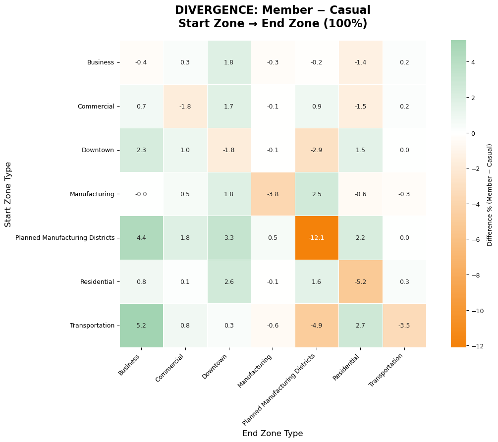

[output not shown]

```
============================================================
STEP 11 — Divergence Heatmap (Member − Casual)
============================================================
  → Zones after grouping  : ['Business', 'Commercial', 'Downtown', 'Manufacturing', 'Planned Manufacturing Districts', 'Residential', 'Transportation']
  → Shape                 : (7, 7)
  → Range                 : [-12.1%  →  5.2%]
  → Cells member > casual : 27  |  casual > member: 19
```

```
  Zone                    Member%  Casual%
  ----------------------------------------
  Business                  22.2%    19.6%
  Commercial                 7.9%     6.8%
  Downtown                  13.1%    11.4%
  Manufacturing              2.0%     1.8%
  Planned Manufac...        40.0%    47.0%
  Residential               13.5%    12.2%
  Transportation             1.2%     1.1%
  ----------------------------------------
  TOTAL                     99.9%    99.9%
```

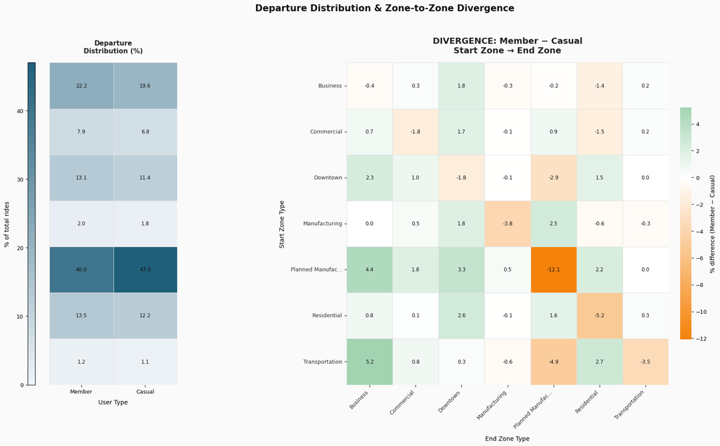

[output not shown]

# 4. Conclusions and Recommendations

↑ back to top

## 4.1 Key Findings

### Temporal patterns

[output not shown]

These patterns are consistent with **members riding primarily for commuting** and  
**casuals riding primarily for leisure**, which has direct implications for conversion strategy.

### Spatial patterns

[output not shown]

## 4.3 Limitations and Potential Biases

[output not shown]

# 5. Saving Outputs

↑ back to top

All visualisations are saved in-line within their respective analysis cells.  
This final cell exports the complete notebook as a self-contained HTML report  
(markdown explanations + all chart outputs, no raw code) to `../reports/`.

```
Successfully created ../reports/cyclistic_analysis.html from 03_analysis_and_visualization.ipynb
Original notebook 03_analysis_and_visualization.ipynb remains unchanged
Cells exported: 56 (markdown + raw as styled box + code outputs only)
```